# Time Series Homework: Chapter 6 Lesson 1 Key

Tristan Farrow

## Data

```r
gdp_ts <- rio::import("https://byuistats.github.io/timeseries/data/gdp_fred.csv") |>
  mutate(year_over_year = gdp_millions / lag(gdp_millions, 4)-1) |>
  mutate(quarter = yearquarter(mdy(quarter))) |>
  filter(quarter >= yearquarter(my("Jan 1990")) & quarter < yearquarter(my("Jan 2025"))) |>
  na.omit() |>
  mutate(t = 1:n()) |>
  mutate(std_t = (t - mean(t)) / sd(t)) |>
  as_tsibble(index = quarter)
```

## Questions

### Question 1 - Stationary Model Comparison (20 points)

We have worked with AR(p), MA(q), ARMA(p,q) stochastic processes. The theoretical ACF and PACF functions of each model can help us identify which of the three models would be a good fit for a particular time series. From the Time Series Notebook:

**ACF and PACF of an $AR(p)$ Process**

|  | AR(p) | MA(q) | ARMA(p,q) |
| --- | --- | --- | --- |
| ACF | Tails off | Cuts off after lag $q$ | Tails off |
| PACF | Cuts off after lag $p$ | Tails off | Tails off |

The table above summarizes the theoretical functions. Each time series is a realization of the stochastic process, so our sample estimates of these functions might be different. The following questions will walk you through the simulation of each of them to illustrate this point.

#### AR(3) Simulation

```r
n <- 10000  # Number of observations
p <- c(0.5, 0.3, 0.1)  # AR coefficients

# Simulate the AR(3) process
set.seed(123)  # Setting seed for reproducibility
ar3_process <- arima.sim(n = n, model = list(ar = p), sd = 1)
ar3_df <- tibble(time = 1:n, value = ar3_process)# Convert the df to a tibble
ar_3 <- as_tsibble(ar3_df, index = time) # Convert the tibble to a tsibble
```

#### MA(3) Simulation

```r
n <- 10000  # Number of observations
q <- c(-0.7, -0.5, 0.2)  # MA coefficients

# Simulate the MA(3) process
set.seed(123)  # For reproducibility
ma3_process <- arima.sim(n = n, model = list(ma = q), sd = 1)
ma_3 <- as_tsibble(tibble(Time = 1:n, value = ma3_process), index = Time) # Convert the simulated MA(3) process to a tsibble
```

##### a) Plot the ACFs for the AR(3) and MA(3) simulations side by side.

**Answer**

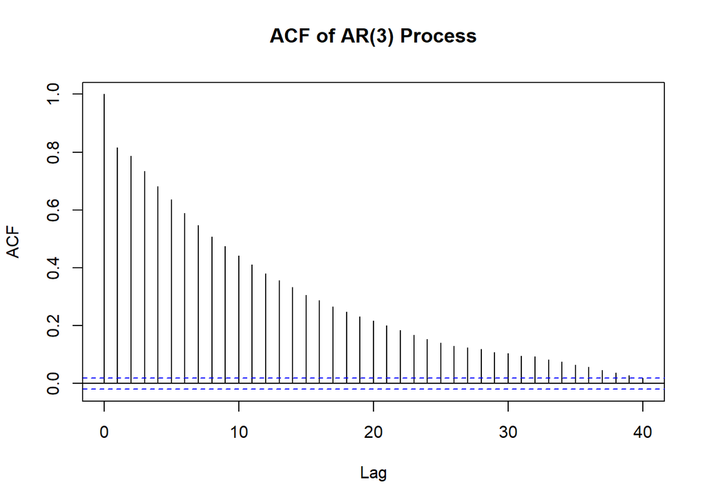

```r
acf_plot_ar3 <- acf(ar3_process, lag.max = 40, main = "ACF of AR(3) Process")
```

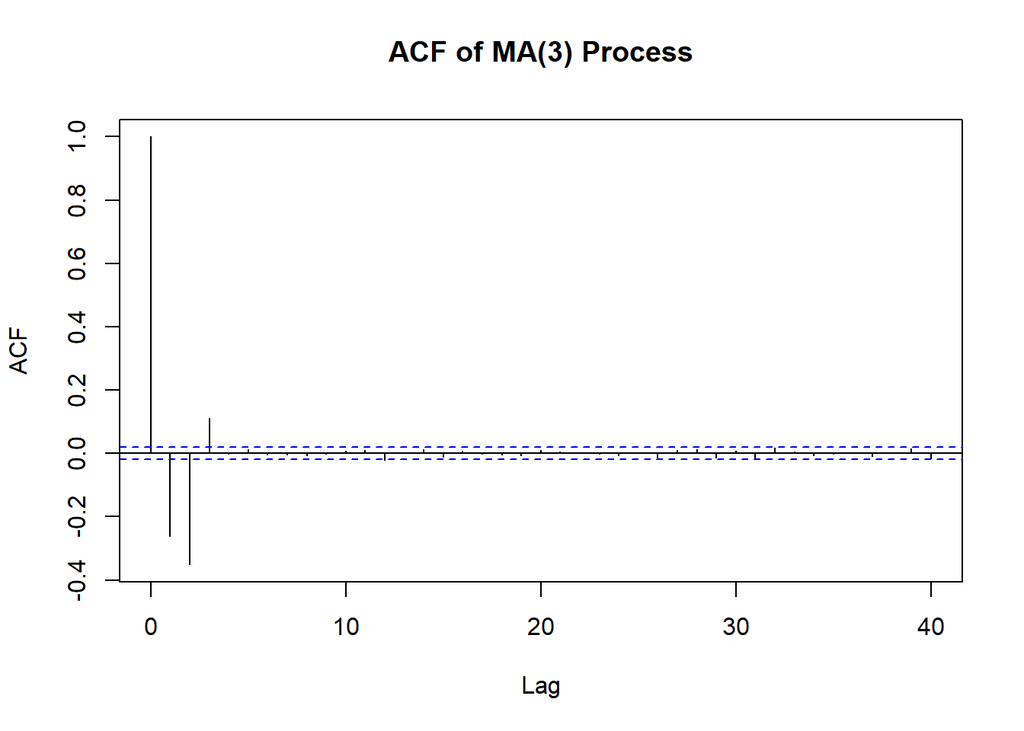

```r
acf_plot_ma3 <- acf(ma3_process, lag.max = 40, main = "ACF of MA(3) Process")
```

##### b) Plot the PACFs for the AR(3) and MA(3) simulations side by side.

**Answer**

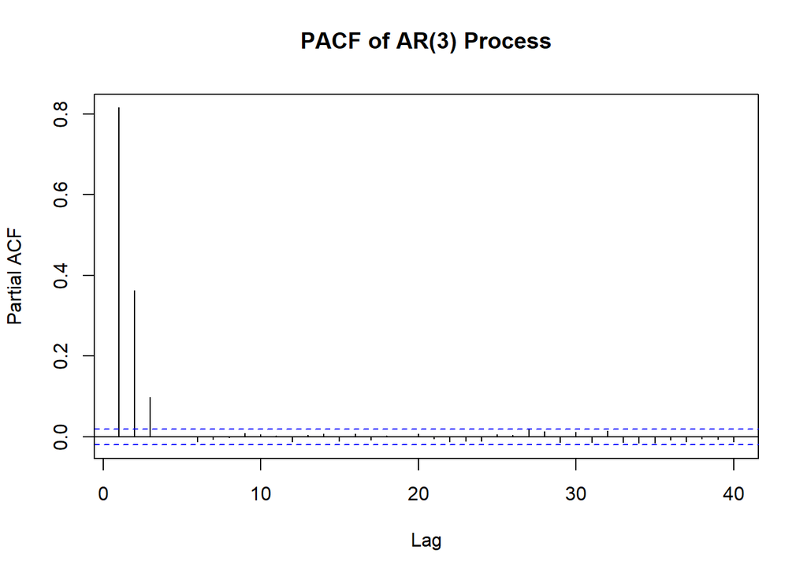

```r
pacf_plot_ar3 <- pacf(ar3_process, lag.max = 40, main = "PACF of AR(3) Process")
```

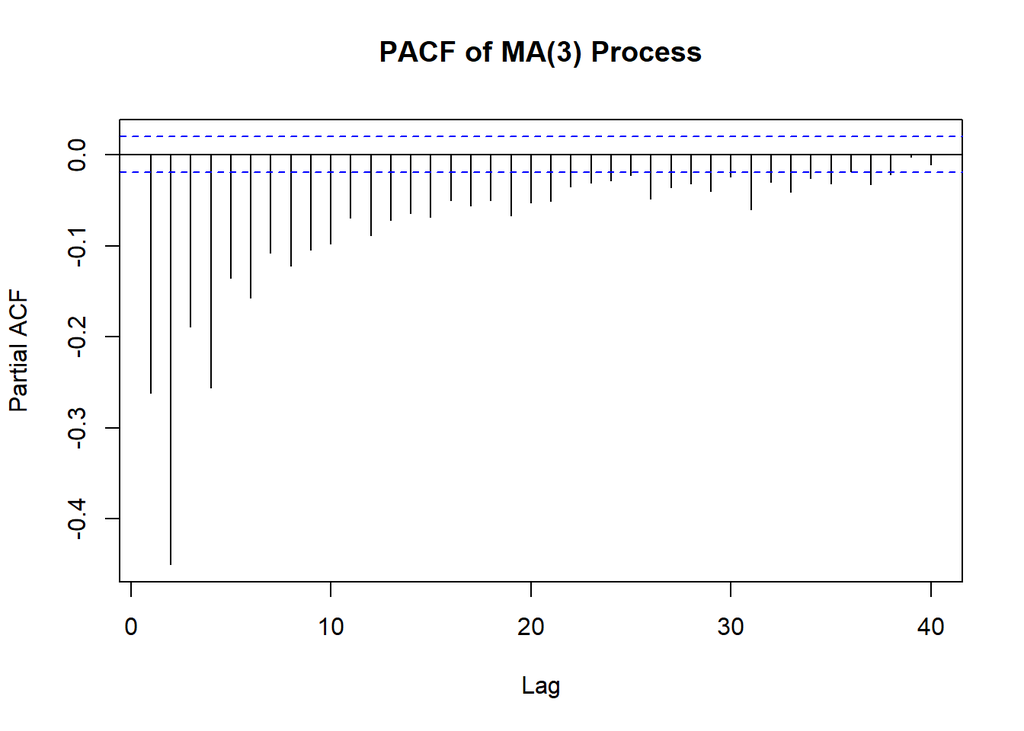

```r
pacf_plot_m3 <- pacf(ma3_process, lag.max = 40, main = "PACF of MA(3) Process")
```

##### c) Does the theoretical ACF and PACF functions described above in Table 1 match with the plots you created? Please change the seed for the simulation multiple times before answering this question.

**Answer**

### Question 2 - Experimentation

#### a) Go back to the simulation and change the parameters used in the AR process. Show that your new parameters are stationary.

```r
n <- 10000
p <- c(0.6, -0.2, 0.2)  #  AR coefficients - HERE

# Simulate the AR(3) process
set.seed(42)  # Setting seed for reproducibility
ar3_process2 <- arima.sim(n = n, model = list(ar = p), sd = 1)
ar3_df <- tibble(time = 1:n, value = ar3_process)# Convert the df to a tibble
ar_3 <- as_tsibble(ar3_df, index = time) # Convert the tibble to a tsibble
```

#### b.) Go back to the simulation and change the parameters used in the MA process. Show that the new parameters are invertible.

```r
n <- 10000  # Number of observations
q <- c(0.4, 0.3, 0.2)  # MA coefficients - HERE

# Simulate the MA(3) process
set.seed(42)  # For reproducibility
ma3_process2 <- arima.sim(n = n, model = list(ma = q), sd = 1)
ma_3 <- as_tsibble(tibble(Time = 1:n, value = ma3_process), index = Time) # Convert the simulated MA(3) process to a tsibble
```

#### c.) Plot the acf and pacf of the new simulations. Are the charts still consistent with the table above?

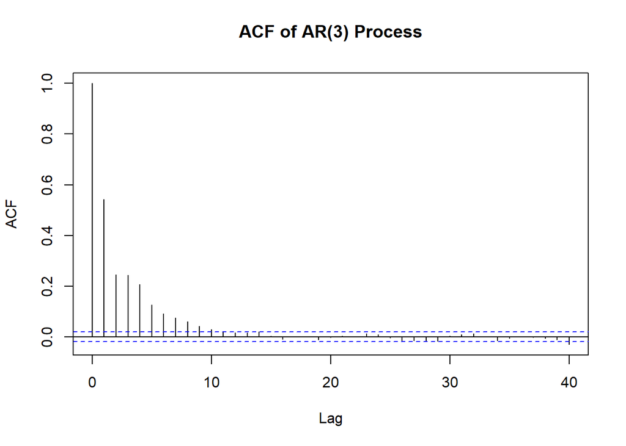

```r
new_acf_plot_ar3 <- acf(ar3_process2, max.lag = 40, main = "ACF of AR(3) Process")
```

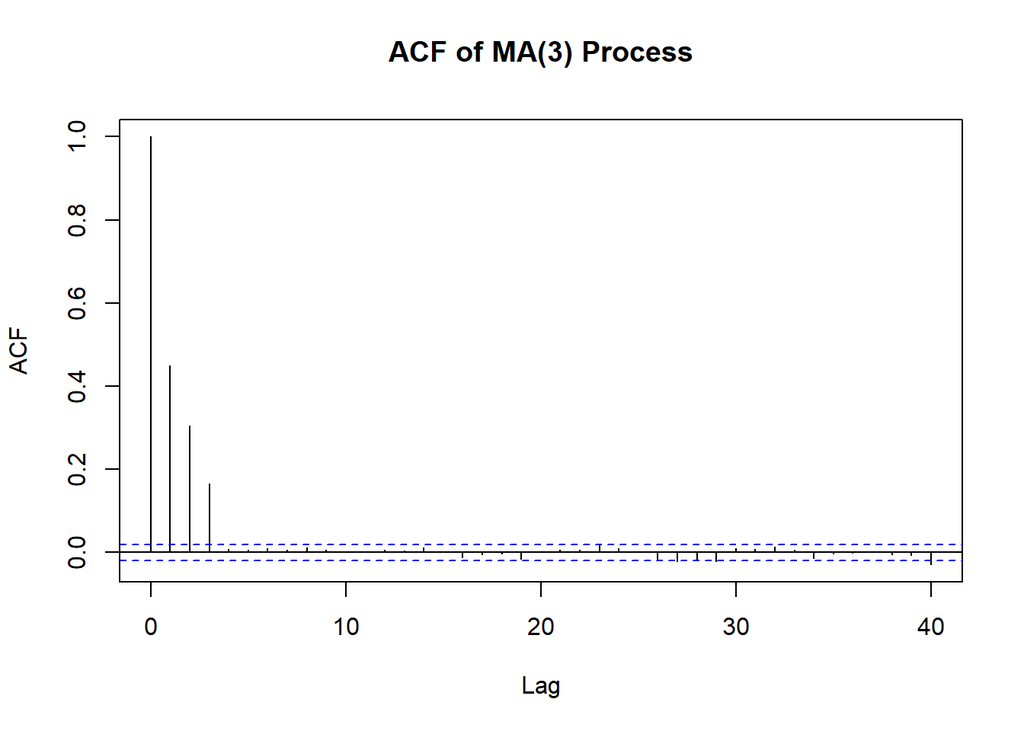

```r
new_acf_plot_ma3 <- acf(ma3_process2, max.lag = 40, main = "ACF of MA(3) Process")
```

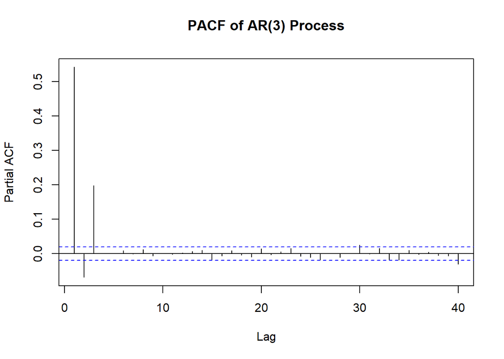

```r
new_pacf_plot_ar3 <- pacf(ar3_process2, max.lag = 40, main = "PACF of AR(3) Process")
```

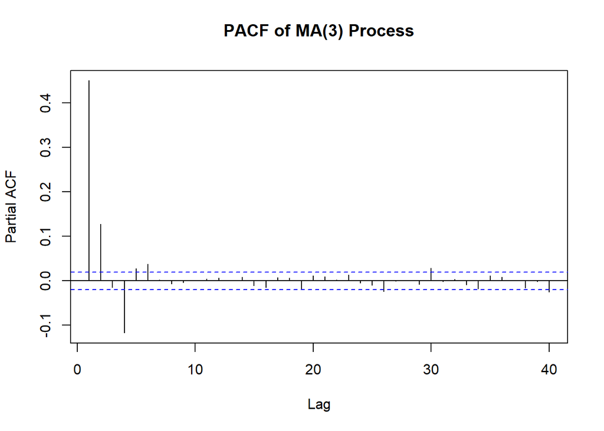

```r
new_pacf_plot_ma3 <- pacf(ma3_process2, max.lag = 40, main = "PACF of MA(3) Process")
```

**Answer**

#### d.) Pick parameters for the MA process that would make the ACF and PACF charts difficult to interept according to the table. Why do you think those parameter values are problematic?

```r
n <- 10000  # Number of observations
q <- c(-0.05, 0.03, -0.02)  # MA coefficients - HERE

# Simulate the MA(3) process
set.seed(123)  # For reproducibility
ma3_process <- arima.sim(n = n, model = list(ma = q), sd = 1)
ma_3 <- as_tsibble(tibble(Time = 1:n, value = ma3_process), index = Time) # Convert the simulated MA(3) process to a tsibble
```

**Answer**

The ACF values are very small making it difficult because they will be close to the confidence interval.

### Rubric

[output not shown]